# Bridge Analysis

DX Analytics https://dxan.co.uk

01 January 2021

> Use case of bridge data analysis: Part II Analytics: Risk factors & Forecasts

# 1 Structurally deficient structures

Plot % bridges in poor general condition (structurally deficient,SD) in 2010 and 2018

- States that show an increase in % of SD bridges are highlighted
- Percentages are marked on the bar

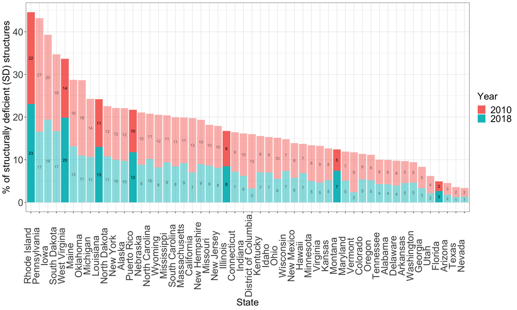

# 2 Risk factors

**Question:** What structure-specific risk factors in 2010 are most predictive of **OUTCOME** in 2018?

- For all models, training data = 2010-2017, test data = 2018.
- Different outcomes could be included.
- Influential predictors are ranked: variables with large absolute values are the most influential.
- Blue (Red) = push up (down) the likelihood of future poor condition.
- Coefficients are for standardized predictors - used for ranking, not for interpretation.

> The following analytics used advanced statistical modelling. Machine learning methods yield little gain on the already excellent performance & are at huge computational cost.

## 2.1 Outcome: Structural deficiency in 2018

### Risk factor: states

- 52 states
- Blue (Red) = push up (down) the likelihood of future poor condition.
- The higher the bar in absolute values, the stronger the influence

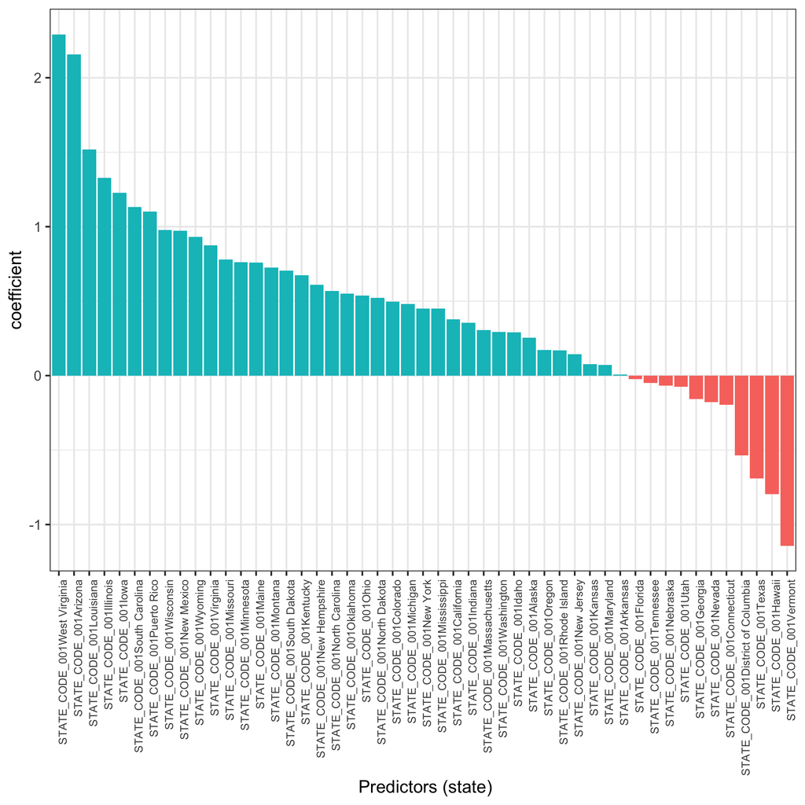

### Risk factor: bridge features

- 220 features (after spreading each category into a dummy) auto-scanned
- List the top 20 features that push up (blue) or down (red) the likelihood of a poor condition in 2018
- The higher the bar in absolute values, the stronger the influence

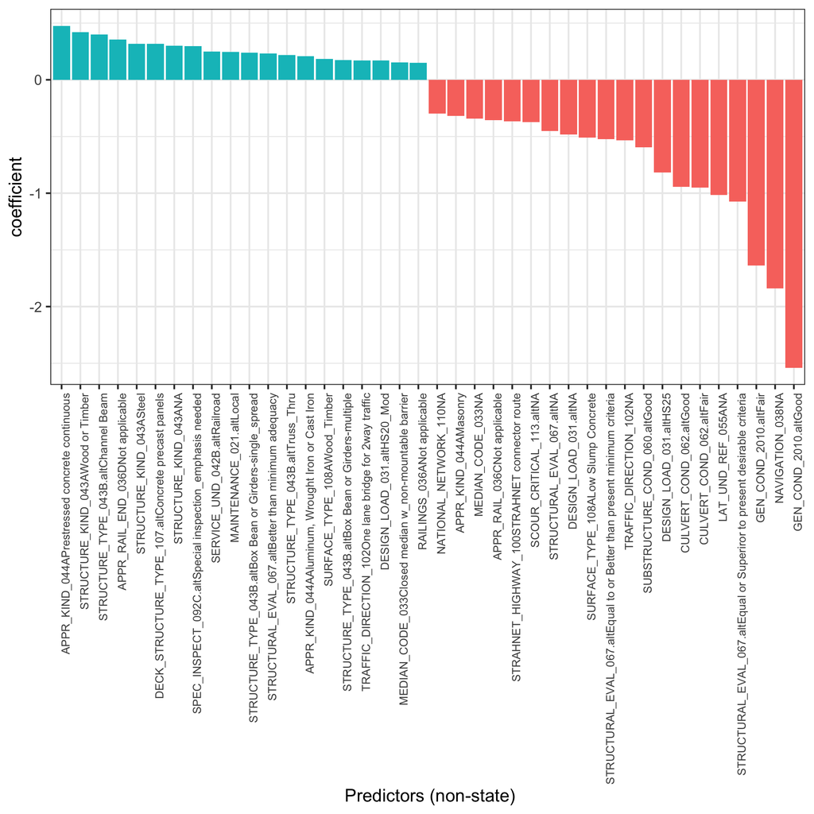

### Model fit

- NB: Reference level for [AUC] area under Receiver Operating Characteristic (ROC) curve = 0.50 (random prediction), with values > 0.8 regarded as good discrimination.

```
Training data performance
```

- [AUC] area under Receiver Operating Characteristic (ROC) curve = 0.91
- Percent correctly predicted = 94 %

```
Test data performance (2018)
```

- [AUC] area under Receiver Operating Characteristic (ROC) curve = 0.9
- Percent correctly predicted = 93 %

## 2.2 Outcome: Total cost in 2018

### Risk factor: states

- 52 states
- Blue (Red) = push up (down) the likelihood of future poor condition.
- The higher the bar in absolute values, the stronger the influence

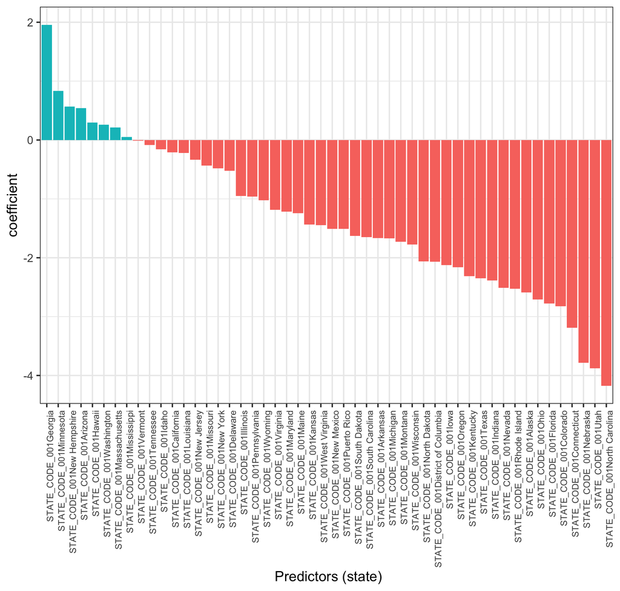

### Risk factor: bridge features

- 220 features (after spreading each category into a dummy) auto-scanned
- List the top 20 features that push up (blue) or down (red) the likelihood of a poor condition in 2018
- The higher the bar in absolute values, the stronger the influence

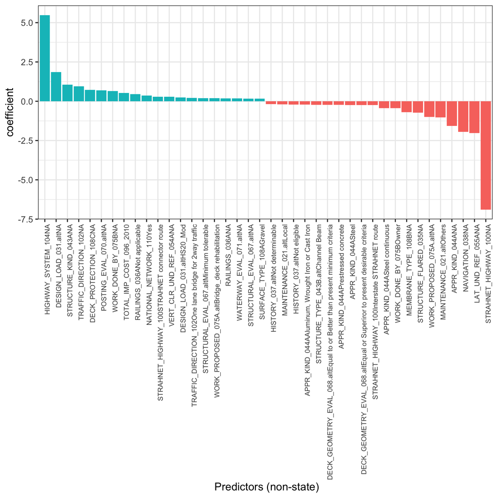

### Model fit

```
Training data performance
```

- R-squared = 0.79

```
Test data performance (2018)
```

- R-squared = 0.8

# 3 Forecasts

- Forecasting requires the advanced use of analytics, and is the core for predictive maintenance.
- Each question requires a **bespoke** approach.
- List of potential questions we can explore:

```
Asset owner level
```

1. Which 10 states will have highest total cost (in 2, 4, 8 years)
2. In each state, which 10 bridges will have highest total cost (in 2, 4, 8 years)
3. In each state, which 10 bridges will have highest prob. of dropping a category (in 2, 4, 8 years)
4. In each state, which 10 bridges will have highest risk of becoming structurally deficient (in 2, 4, 8 years)

```
Specific asset level
```

1. For a given bridge with fair/good status, when would it become structurally deficient?
2. For a given bridge, what is the cost estimate over time?